# PredictionAssignment

Rukshan Wijekoon

September 7, 2017

## Background

Using devices such as Jawbone Up, Nike FuelBand, and Fitbit it is now possible to collect a large amount of data about personal activity relatively inexpensively. These type of devices are part of the quantified self movement – a group of enthusiasts who take measurements about themselves regularly to improve their health, to find patterns in their behavior, or because they are tech geeks. One thing that people regularly do is quantify how much of a particular activity they do, but they rarely quantify how well they do it. In this project, your goal will be to use data from accelerometers on the belt, forearm, arm, and dumbell of 6 participants. They were asked to perform barbell lifts correctly and incorrectly in 5 different ways. More information is available from the website here:

http://web.archive.org/web/20161224072740/http:/groupware.les.inf.puc-rio.br/har (see the section on the Weight Lifting Exercise Dataset).

## Data

The training data for this project are available here:

https://d396qusza40orc.cloudfront.net/predmachlearn/pml-training.csv

The test data are available here:

https://d396qusza40orc.cloudfront.net/predmachlearn/pml-testing.csv

## Loading Data

Let’s load the data and create the setup to analyse the dataset.

```r
library(caret)

testData <- read.csv("data/pml-testing.csv")
trainData <- read.csv("data/pml-training.csv")
```

We first remove all columns that contains NA and remove freatures that are not in the testing dataset.

```r
features <- names(testData[ , colSums(is.na(testData)) == 0])[8:59]

# Let's use only these features
trainData <- trainData[ , c(features, "classe")]
testData <- testData[ , c(features, "problem_id")]
```

## Partitioning Dataset

Let’s paritition the dataset

```r
set.seed(34527)

inTrain <- createDataPartition(trainData$classe, p = 0.6, list = FALSE)

training <- trainData[inTrain, ]
testing <- trainData[-inTrain, ]
```

## Data Analysis

Let’s fit a tree using this dataset.

```r
library(tree)

fitTree <- tree(classe ~. , data = training)
summary(fitTree)
```

```
##
## Classification tree:
## tree(formula = classe ~ ., data = training)
## Variables actually used in tree construction:
##  [1] "roll_belt"            "pitch_forearm"        "roll_forearm"
##  [4] "magnet_dumbbell_x"    "magnet_dumbbell_y"    "magnet_dumbbell_z"
##  [7] "roll_arm"             "yaw_belt"             "total_accel_dumbbell"
## [10] "accel_forearm_x"
## Number of terminal nodes:  15
## Residual mean deviance:  1.808 = 21260 / 11760
## Misclassification error rate: 0.3637 = 4283 / 11776
```

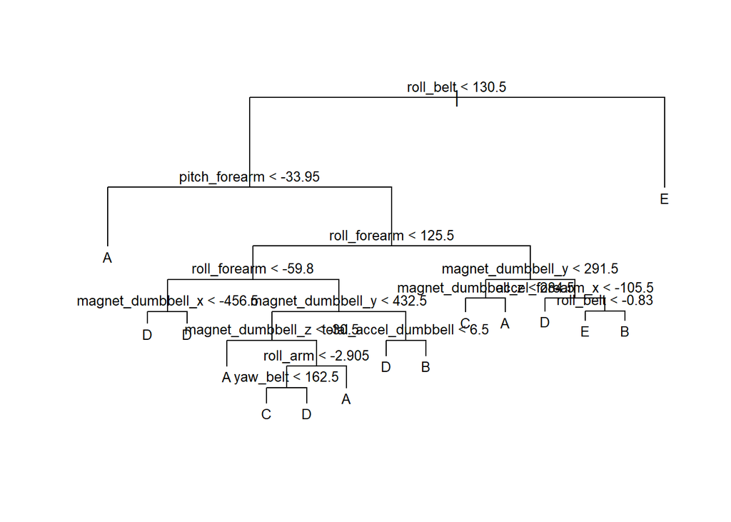

```r
plot(fitTree)
text(fitTree, pretty = 0, cex = 0.8)
```

## Cross Validataion

Now let’s perform a cross validataion to check performance of the tree.

```r
treePred <- predict(fitTree, testing, type = "class")

confusionMatrix(treePred, testing$classe)
```

```
## Confusion Matrix and Statistics
##
##           Reference
## Prediction    A    B    C    D    E
##          A 1737  367  113   43   49
##          B   62  585  114   57  181
##          C   91  143  923  190  145
##          D  333  423  218  970  305
##          E    9    0    0   26  762
##
## Overall Statistics
##
##                Accuracy : 0.6343
##                  95% CI : (0.6236, 0.645)
##     No Information Rate : 0.2845
##     P-Value [Acc > NIR] : < 2.2e-16
##
##                   Kappa : 0.5388
##  Mcnemar's Test P-Value : < 2.2e-16
##
## Statistics by Class:
##
##                      Class: A Class: B Class: C Class: D Class: E
## Sensitivity            0.7782  0.38538   0.6747   0.7543  0.52843
## Specificity            0.8981  0.93458   0.9122   0.8050  0.99453
## Pos Pred Value         0.7523  0.58559   0.6186   0.4313  0.95609
## Neg Pred Value         0.9106  0.86374   0.9300   0.9435  0.90353
## Prevalence             0.2845  0.19347   0.1744   0.1639  0.18379
## Detection Rate         0.2214  0.07456   0.1176   0.1236  0.09712
## Detection Prevalence   0.2943  0.12733   0.1902   0.2866  0.10158
## Balanced Accuracy      0.8382  0.65998   0.7934   0.7797  0.76148
```

# Random Foreset Model

Using random forest, let’s try to minimize the out of sample error.

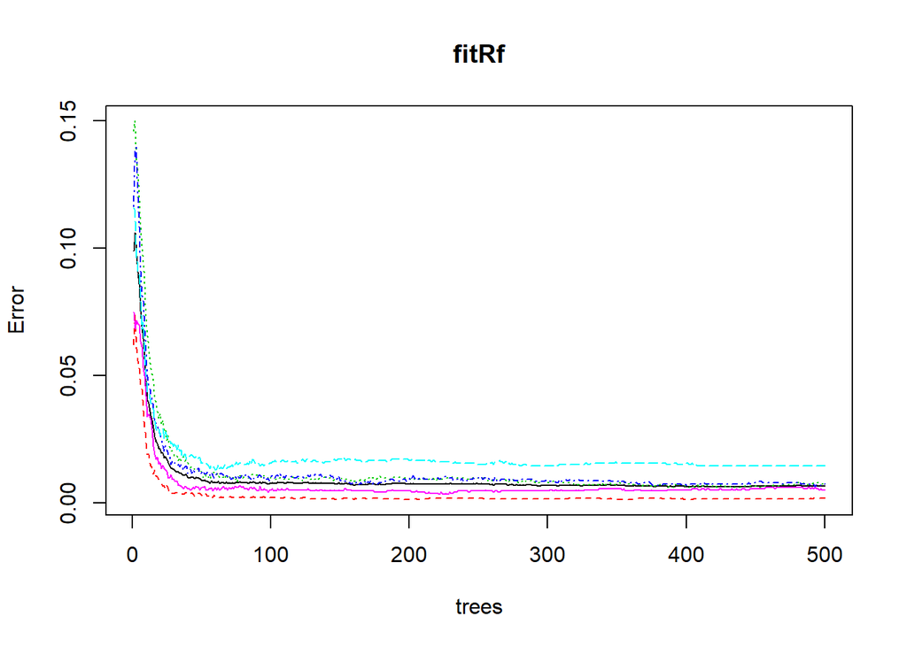

```r
library(randomForest)
fitRf <- randomForest(classe ~., data = training, method = "rf",
                      importance = T, trControl = trainControl(method = "cv",
                      classProbs = TRUE, savePredictions = TRUE, allowParallel = TRUE, number = 10))

plot(fitRf)
```

## Predicting with Random Forest Model

```r
pred <- predict(fitRf, testing, type = "class")
confusionMatrix(pred, testing$classe)
```

```
## Confusion Matrix and Statistics
##
##           Reference
## Prediction    A    B    C    D    E
##          A 2227    7    0    0    0
##          B    4 1509   12    0    0
##          C    0    2 1355   22    1
##          D    0    0    1 1264    3
##          E    1    0    0    0 1438
##
## Overall Statistics
##
##                Accuracy : 0.9932
##                  95% CI : (0.9912, 0.9949)
##     No Information Rate : 0.2845
##     P-Value [Acc > NIR] : < 2.2e-16
##
##                   Kappa : 0.9915
##  Mcnemar's Test P-Value : NA
##
## Statistics by Class:
##
##                      Class: A Class: B Class: C Class: D Class: E
## Sensitivity            0.9978   0.9941   0.9905   0.9829   0.9972
## Specificity            0.9988   0.9975   0.9961   0.9994   0.9998
## Pos Pred Value         0.9969   0.9895   0.9819   0.9968   0.9993
## Neg Pred Value         0.9991   0.9986   0.9980   0.9967   0.9994
## Prevalence             0.2845   0.1935   0.1744   0.1639   0.1838
## Detection Rate         0.2838   0.1923   0.1727   0.1611   0.1833
## Detection Prevalence   0.2847   0.1944   0.1759   0.1616   0.1834
## Balanced Accuracy      0.9983   0.9958   0.9933   0.9911   0.9985
```

Random forest model seems to be more accurate.

## Predictions on Testing Data

```r
predicts <- predict(fitRf, testData)
predicts
```

```
##  1  2  3  4  5  6  7  8  9 10 11 12 13 14 15 16 17 18 19 20
##  B  A  B  A  A  E  D  B  A  A  B  C  B  A  E  E  A  B  B  B
## Levels: A B C D E
```